# Factors associated with stroke in adults: a multivariable analysis with multiple imputation

Cross-sectional analysis of the Kaggle stroke prediction dataset

Author

Published

September 20, 2026

## 1. Objective and analysis plan

**Objective.** To describe the factors associated with a history of stroke among adults, with a focus on the association between **hypertension** (primary exposure) and stroke, after adjustment for potential confounders.

**Design.** Cross-sectional analysis of a public dataset (source not documented; no follow-up time). Results are therefore **associations, not causal effects and not incidence or prediction of future stroke**.

**Population.** Adults (age >= 18 years).

**Outcome.** Stroke (binary, yes/no).

**Covariates.** Age, sex, heart disease, average glucose level, BMI, smoking status.

**Missing data.**

- BMI is missing for a subset of adults. These participants are **kept** in the analysis using multivariate imputation by chained equations (MICE, m = 20), with the outcome included in the imputation model.
- Smoking status “Unknown” is kept as its own category in the main model.
- Sensitivity analyses: (1) complete-case analysis, (2) exclusion of “Unknown” smoking status.

**Statistical model.** Multivariable logistic regression; results as odds ratios (OR) with 95% confidence intervals, pooled across imputed datasets with Rubin’s rules.

```r
# install.packages(c("tidyverse", "gtsummary", "gt", "mice", "broom", "car", "scales"))
library(tidyverse)
library(gtsummary)
library(gt)
library(mice)

theme_set(theme_minimal(base_size = 12))
set.seed(2026)
```

## 2. Data and sample selection

Place `healthcare-dataset-stroke-data.csv` in the same folder as this `.qmd` file.

```r
raw <- read_csv(
  "healthcare-dataset-stroke-data.csv",
  na = c("N/A", "NA", ""),
  show_col_types = FALSE
)

glimpse(raw)
```

```
Rows: 5,110
Columns: 12
$ id                <dbl> 9046, 51676, 31112, 60182, 1665, 56669, 53882, 10434…
$ gender            <chr> "Male", "Female", "Male", "Female", "Female", "Male"…
$ age               <dbl> 67, 61, 80, 49, 79, 81, 74, 69, 59, 78, 81, 61, 54, …
$ hypertension      <dbl> 0, 0, 0, 0, 1, 0, 1, 0, 0, 0, 1, 0, 0, 0, 0, 1, 0, 1…
$ heart_disease     <dbl> 1, 0, 1, 0, 0, 0, 1, 0, 0, 0, 0, 1, 0, 1, 1, 0, 1, 0…
$ ever_married      <chr> "Yes", "Yes", "Yes", "Yes", "Yes", "Yes", "Yes", "No…
$ work_type         <chr> "Private", "Self-employed", "Private", "Private", "S…
$ Residence_type    <chr> "Urban", "Rural", "Rural", "Urban", "Rural", "Urban"…
$ avg_glucose_level <dbl> 228.69, 202.21, 105.92, 171.23, 174.12, 186.21, 70.0…
$ bmi               <dbl> 36.6, NA, 32.5, 34.4, 24.0, 29.0, 27.4, 22.8, NA, 24…
$ smoking_status    <chr> "formerly smoked", "never smoked", "never smoked", "…
$ stroke            <dbl> 1, 1, 1, 1, 1, 1, 1, 1, 1, 1, 1, 1, 1, 1, 1, 1, 1, 1…
```

```r
adults <- raw |>
  filter(age >= 18, gender != "Other") |>
  mutate(
    stroke_f       = factor(stroke, levels = c(0, 1), labels = c("No stroke", "Stroke")),
    gender         = factor(gender, levels = c("Female", "Male")),
    hypertension   = factor(hypertension, levels = c(0, 1), labels = c("No", "Yes")),
    heart_disease  = factor(heart_disease, levels = c(0, 1), labels = c("No", "Yes")),
    smoking_status = factor(
      smoking_status,
      levels = c("never smoked", "formerly smoked", "smokes", "Unknown")
    )
  )

flow <- tribble(
  ~Step,                                   ~N,
  "Records in dataset",                    nrow(raw),
  "Excluded: age < 18",                    sum(raw$age < 18),
  "Excluded: gender 'Other'",              sum(raw$age >= 18 & raw$gender == "Other"),
  "Analytic sample (adults)",              nrow(adults),
  "   with stroke",                        sum(adults$stroke),
  "   with BMI missing",                   sum(is.na(adults$bmi))
)

gt(flow)
```

| Step | N |
| --- | --- |
| Records in dataset | 5110 |
| Excluded: age < 18 | 856 |
| Excluded: gender 'Other' | 1 |
| Analytic sample (adults) | 4253 |
| with stroke | 247 |
| with BMI missing | 181 |

## 3. Descriptive analysis

### 3.1 Table 1

```r
adults |>
  select(stroke_f, age, gender, hypertension, heart_disease,
         avg_glucose_level, bmi, smoking_status) |>
  tbl_summary(
    by = stroke_f,
    label = list(
      age ~ "Age, years",
      gender ~ "Sex",
      hypertension ~ "Hypertension",
      heart_disease ~ "Heart disease",
      avg_glucose_level ~ "Average glucose, mg/dL",
      bmi ~ "BMI, kg/m2",
      smoking_status ~ "Smoking status"
    ),
    statistic = list(all_continuous() ~ "{median} ({p25}, {p75})"),
    missing = "ifany",
    missing_text = "Missing"
  ) |>
  add_overall() |>
  add_p() |>
  bold_labels()
```

| **Characteristic** | **Overall** N = 4,253<sup>1</sup> | **No stroke** N = 4,006<sup>1</sup> | **Stroke** N = 247<sup>1</sup> | **p-value**<sup>2</sup> |
| --- | --- | --- | --- | --- |
| Age, years | 51 (36, 64) | 49 (35, 62) | 71 (59, 78) | <0.001 |
| Sex |  |  |  | 0.2 |
| Female | 2,576 (61%) | 2,437 (61%) | 139 (56%) |  |
| Male | 1,677 (39%) | 1,569 (39%) | 108 (44%) |  |
| Hypertension | 497 (12%) | 431 (11%) | 66 (27%) | <0.001 |
| Heart disease | 275 (6.5%) | 228 (5.7%) | 47 (19%) | <0.001 |
| Average glucose, mg/dL | 92 (77, 116) | 92 (77, 114) | 106 (80, 197) | <0.001 |
| BMI, kg/m2 | 29 (25, 34) | 29 (25, 34) | 30 (26, 34) | 0.5 |
| Missing | 181 | 142 | 39 |  |
| Smoking status |  |  |  | 0.013 |
| never smoked | 1,752 (41%) | 1,662 (41%) | 90 (36%) |  |
| formerly smoked | 859 (20%) | 789 (20%) | 70 (28%) |  |
| smokes | 780 (18%) | 738 (18%) | 42 (17%) |  |
| Unknown | 862 (20%) | 817 (20%) | 45 (18%) |  |

<sup>1</sup> Median (Q1, Q3); n (%)  
<sup>2</sup> Wilcoxon rank sum test; Pearson’s Chi-squared test

### 3.2 Who has missing BMI?

Before choosing a missing-data strategy, check whether missingness is related to other variables and to the outcome.

```r
adults |>
  mutate(bmi_status = if_else(is.na(bmi), "BMI missing", "BMI observed")) |>
  select(bmi_status, stroke_f, age, gender, hypertension,
         heart_disease, avg_glucose_level, smoking_status) |>
  tbl_summary(
    by = bmi_status,
    label = list(stroke_f ~ "Stroke"),
    statistic = list(all_continuous() ~ "{median} ({p25}, {p75})")
  ) |>
  add_p() |>
  bold_labels()
```

| **Characteristic** | **BMI missing** N = 181<sup>1</sup> | **BMI observed** N = 4,072<sup>1</sup> | **p-value**<sup>2</sup> |
| --- | --- | --- | --- |
| Stroke |  |  | <0.001 |
| No stroke | 142 (78%) | 3,864 (95%) |  |
| Stroke | 39 (22%) | 208 (5.1%) |  |
| age | 60 (43, 72) | 50 (36, 63) | <0.001 |
| gender |  |  | <0.001 |
| Female | 88 (49%) | 2,488 (61%) |  |
| Male | 93 (51%) | 1,584 (39%) |  |
| hypertension | 47 (26%) | 450 (11%) | <0.001 |
| heart_disease | 33 (18%) | 242 (5.9%) | <0.001 |
| avg_glucose_level | 101 (82, 196) | 92 (77, 115) | <0.001 |
| smoking_status |  |  | <0.001 |
| never smoked | 38 (21%) | 1,714 (42%) |  |
| formerly smoked | 46 (25%) | 813 (20%) |  |
| smokes | 52 (29%) | 728 (18%) |  |
| Unknown | 45 (25%) | 817 (20%) |  |

<sup>1</sup> n (%); Median (Q1, Q3)  
<sup>2</sup> Pearson’s Chi-squared test; Wilcoxon rank sum test

> **To write after rendering:** if the proportion of stroke differs between the two groups, missingness is not completely at random (MCAR). Dropping these participants could bias results, which motivates multiple imputation under a missing-at-random (MAR) assumption.

### 3.3 Glucose: is a linear term reasonable?

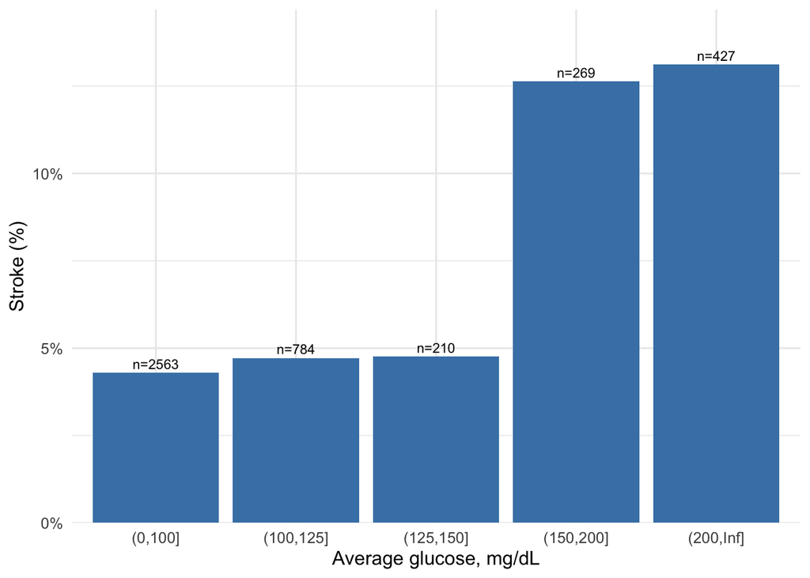

Figure 1: Proportion with stroke by average glucose category (adults)

```r
adults |>
  mutate(glucose_bin = cut(avg_glucose_level, breaks = c(0, 100, 125, 150, 200, Inf))) |>
  group_by(glucose_bin) |>
  summarise(n = n(), events = sum(stroke), risk = events / n, .groups = "drop") |>
  ggplot(aes(glucose_bin, risk)) +
  geom_col(fill = "steelblue") +
  geom_text(aes(label = paste0("n=", n)), vjust = -0.4, size = 3) +
  scale_y_continuous(labels = scales::percent, expand = expansion(mult = c(0, 0.12))) +
  labs(x = "Average glucose, mg/dL", y = "Stroke (%)")
```

> **To write after rendering:** the relationship may not be linear on the log-odds scale. The main model uses a linear glucose term for simplicity; this is listed as a limitation.

## 4. Multiple imputation

```r
# Scale continuous variables so that ORs are interpretable
dat <- adults |>
  transmute(
    stroke,
    age_10        = age / 10,
    gender,
    hypertension,
    heart_disease,
    glucose_10    = avg_glucose_level / 10,
    bmi_5         = bmi / 5,
    smoking_status
  )

colSums(is.na(dat))
```

```
        stroke         age_10         gender   hypertension  heart_disease
             0              0              0              0              0
    glucose_10          bmi_5 smoking_status
             0            181              0
```

```r
imp <- mice(dat, m = 20, maxit = 10, seed = 2026, printFlag = FALSE)

imp$method[imp$method != ""]   # which variables were imputed, and how
```

```
bmi_5
"pmm"
```

Convergence and plausibility checks:

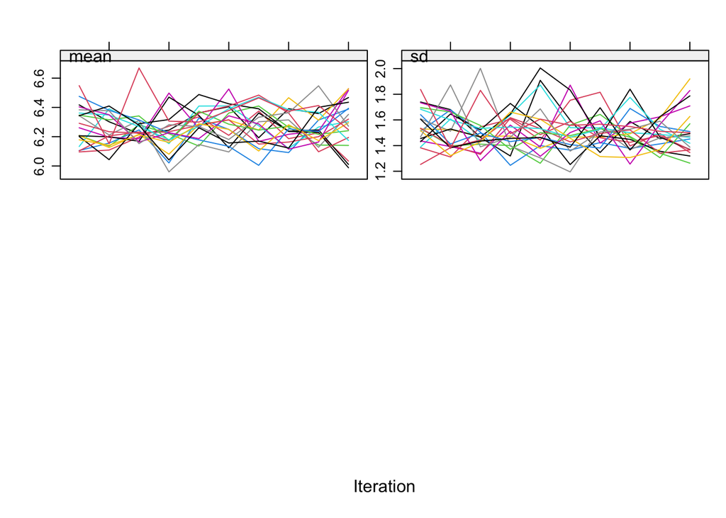

```r
plot(imp, "bmi_5")
```

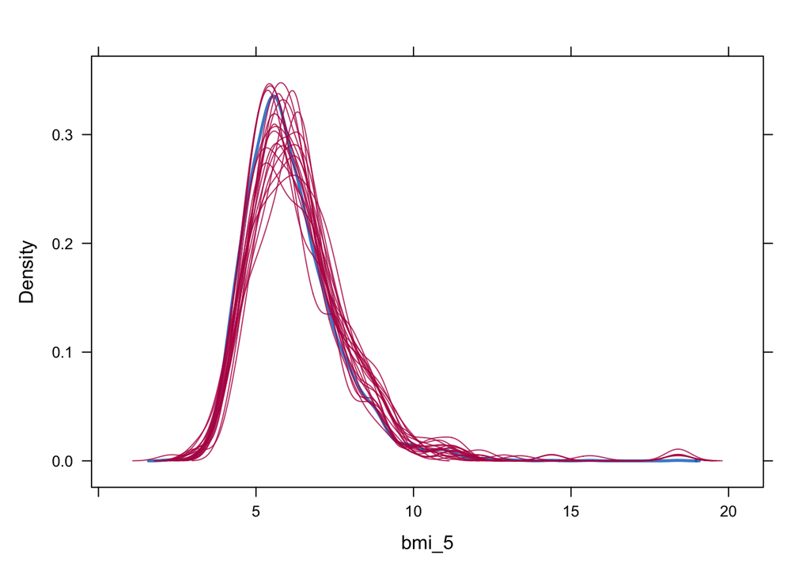

```r
densityplot(imp, ~ bmi_5)
```

> Imputed values (red) should look reasonably similar to observed values (blue). Small differences are expected because BMI is missing more often among people with stroke.

## 5. Multivariable logistic regression

```r
# Extract pooled ORs with 95% CI from a mice pooled object
tidy_pool <- function(p) {
  # Version-independent: compute the CI from the pooled log-OR, its SE and
  # Rubin's degrees of freedom, then exponentiate.
  summary(p) |>
    as_tibble() |>
    transmute(
      term,
      estimate  = exp(estimate),
      conf.low  = exp(log(estimate) - qt(0.975, df) * std.error),
      conf.high = exp(log(estimate) + qt(0.975, df) * std.error),
      p.value
    )
}

# Fit a logistic model on each imputed dataset (data passed explicitly),
# then pool with Rubin's rules and return ORs with 95% CI
fit_pool <- function(imp, formula) {
  fits <- lapply(
    mice::complete(imp, "all"),
    function(d) glm(formula, data = d, family = binomial)
  )
  tidy_pool(pool(as.mira(fits)))
}

fmt_or <- function(est, lo, hi) sprintf("%.2f (%.2f-%.2f)", est, lo, hi)

term_labels <- c(
  "age_10"                        = "Age (per 10 years)",
  "genderMale"                    = "Male (vs female)",
  "hypertensionYes"               = "Hypertension (yes vs no)",
  "heart_diseaseYes"              = "Heart disease (yes vs no)",
  "glucose_10"                    = "Average glucose (per 10 mg/dL)",
  "bmi_5"                         = "BMI (per 5 kg/m2)",
  "smoking_statusformerly smoked" = "Former smoker (vs never)",
  "smoking_statussmokes"          = "Current smoker (vs never)",
  "smoking_statusUnknown"         = "Smoking status unknown (vs never)"
)

model_formula <- stroke ~ age_10 + gender + hypertension + heart_disease +
  glucose_10 + bmi_5 + smoking_status
```

### 5.1 Main model (multiple imputation)

```r
res_main <- fit_pool(imp, model_formula)
```

### 5.2 Crude vs adjusted odds ratios

Comparing crude and adjusted estimates shows which associations are affected by confounding (age is the obvious candidate).

```r
predictors <- c("age_10", "gender", "hypertension", "heart_disease",
                "glucose_10", "bmi_5", "smoking_status")

res_crude <- map_dfr(predictors, function(v) {
  fit_pool(imp, reformulate(v, response = "stroke"))
}) |>
  filter(term != "(Intercept)")

comp <- res_main |>
  filter(term != "(Intercept)") |>
  select(term, est_adj = estimate, lo_adj = conf.low, hi_adj = conf.high, p.value) |>
  left_join(
    res_crude |>
      select(term, est_crude = estimate, lo_crude = conf.low, hi_crude = conf.high),
    by = "term"
  ) |>
  mutate(
    Variable        = unname(term_labels[term]),
    `Crude OR`      = fmt_or(est_crude, lo_crude, hi_crude),
    `Adjusted OR`   = fmt_or(est_adj, lo_adj, hi_adj),
    `p (adjusted)`  = scales::pvalue(p.value)
  ) |>
  select(Variable, `Crude OR`, `Adjusted OR`, `p (adjusted)`)

gt(comp) |>
  tab_header(title = "Odds ratios for stroke (95% CI), pooled over 20 imputed datasets") |>
  tab_footnote("Adjusted for all other variables in the table.")
```

Odds ratios for stroke (95% CI), pooled over 20 imputed datasets

[output not shown]

Adjusted for all other variables in the table.

### 5.3 Forest plot

[figure not shown]

```r
res_main |>
  filter(term != "(Intercept)") |>
  mutate(label = factor(unname(term_labels[term]), levels = rev(unname(term_labels)))) |>
  ggplot(aes(x = estimate, y = label)) +
  geom_vline(xintercept = 1, linetype = "dashed", colour = "grey50") +
  geom_pointrange(aes(xmin = conf.low, xmax = conf.high)) +
  scale_x_log10() +
  labs(x = "Adjusted odds ratio (95% CI, log scale)", y = NULL)
```

## 6. Sensitivity analyses

Do the conclusions depend on how missing data are handled?

```r
# (a) Complete-case: glm() silently drops rows with missing BMI
fit_cc <- glm(model_formula, data = dat, family = binomial)
res_cc <- broom::tidy(fit_cc, exponentiate = TRUE, conf.int = TRUE)

# (b) Exclude participants with unknown smoking status, MI for BMI
dat_known <- dat |>
  filter(smoking_status != "Unknown") |>
  mutate(smoking_status = droplevels(smoking_status))

imp_known <- mice(dat_known, m = 20, maxit = 10, seed = 2026, printFlag = FALSE)
res_known <- fit_pool(imp_known, model_formula)

lab_main  <- sprintf("Main: MI for BMI (n = %d)", nrow(dat))
lab_cc    <- sprintf("Complete case (n = %d)", nobs(fit_cc))
lab_known <- sprintf("Smoking known + MI (n = %d)", nrow(dat_known))

sens <- bind_rows(
  res_main  |> mutate(Analysis = lab_main),
  res_cc    |> mutate(Analysis = lab_cc),
  res_known |> mutate(Analysis = lab_known)
) |>
  filter(term != "(Intercept)") |>
  mutate(OR = fmt_or(estimate, conf.low, conf.high)) |>
  select(Analysis, term, OR) |>
  pivot_wider(names_from = Analysis, values_from = OR) |>
  mutate(Variable = unname(term_labels[term]), .before = 1) |>
  select(-term)

gt(sens) |>
  sub_missing(missing_text = "-") |>
  tab_header(title = "Adjusted OR (95% CI) under different missing-data strategies")
```

Adjusted OR (95% CI) under different missing-data strategies

| Variable | Main: MI for BMI (n = 4253) | Complete case (n = 4072) | Smoking known + MI (n = 3391) |
| --- | --- | --- | --- |
| Age (per 10 years) | 2.03 (1.82-2.28) | 1.99 (1.77-2.26) | 2.02 (1.78-2.30) |
| Male (vs female) | 1.04 (0.78-1.37) | 1.00 (0.74-1.35) | 0.97 (0.72-1.33) |
| Hypertension (yes vs no) | 1.48 (1.07-2.04) | 1.68 (1.18-2.35) | 1.62 (1.15-2.28) |
| Heart disease (yes vs no) | 1.33 (0.92-1.94) | 1.45 (0.96-2.15) | 1.38 (0.92-2.08) |
| Average glucose (per 10 mg/dL) | 1.04 (1.02-1.07) | 1.05 (1.02-1.08) | 1.04 (1.01-1.07) |
| BMI (per 5 kg/m2) | 1.00 (0.89-1.13) | 1.01 (0.90-1.13) | 1.02 (0.90-1.16) |
| Former smoker (vs never) | 1.22 (0.86-1.71) | 1.05 (0.73-1.52) | 1.23 (0.87-1.74) |
| Current smoker (vs never) | 1.37 (0.92-2.05) | 1.46 (0.95-2.20) | 1.38 (0.92-2.07) |
| Smoking status unknown (vs never) | 1.14 (0.77-1.68) | 0.80 (0.50-1.26) | - |

## 7. Model checks

```r
# Generalised variance inflation factors (complete-case model)
car::vif(fit_cc)
```

```
                   GVIF Df GVIF^(1/(2*Df))
age_10         1.161606  1        1.077778
gender         1.043450  1        1.021494
hypertension   1.062156  1        1.030610
heart_disease  1.086008  1        1.042117
glucose_10     1.110622  1        1.053860
bmi_5          1.106896  1        1.052091
smoking_status 1.082515  3        1.013302
```

> Values close to 1 indicate no problematic collinearity (rule of thumb: concern above about 5).

## 8. Discussion

**Strengths.** All adults were retained through multiple imputation; crude and adjusted estimates and sensitivity analyses are reported.

**Limitations.**

- **Cross-sectional design and unknown source.** No temporal ordering; the data provenance is undocumented, so generalisability is unknown. Findings are associations only.
- **Missing data.** Multiple imputation assumes MAR. BMI was more often missing among people with stroke; if missingness depends on unobserved factors, estimates may still be biased.
- **Smoking status.** “Unknown” was treated as a separate category; it may not be interchangeable with a true missing value.
- **Linearity.** Glucose (and possibly BMI) was modelled linearly, although descriptive results suggest a non-linear pattern. Splines are a natural extension.
- **Adjustment set.** Heart disease and glucose may lie on the pathway between hypertension and stroke, so the adjusted OR for hypertension may not represent its total association. No formal causal framework (e.g. a DAG) was used.
- **Residual confounding.** Variables such as medication, family history and socioeconomic status are not available.
- **Odds ratios.** With a stroke prevalence of around 5%, ORs approximate risk ratios reasonably well, but they are not identical.

**Possible extensions.** Natural splines for glucose and BMI; age-by-hypertension interaction; prediction models (logistic regression vs random forest) with class-imbalance handling and calibration.